# Practical Machine Learning

# Peer-graded Assignment

## Summury

This report shows the analysis results of the Weight Lifting Exercises Dataset. The aim is to predict human activity from sensor data. The Weight Lifting Exercises Dataset contains 5 class human activity. In this report, I used random forest and recursive feature elimination.

## Data

task:Human Activity Recognition

data:multi sensor time series data

label(class):exactly according to the specification (Class A), throwing the elbows to the front (Class B), lifting the dumbbell only halfway (Class C), lowering the dumbbell only halfway (Class D) and throwing the hips to the front (Class E).(in detail: http://groupware.les.inf.puc-rio.br/har#ixzz4LvubzXo2)

site ulr:http://groupware.les.inf.puc-rio.br/har

## Analysis

### Laod packages

```r
library(caret)
library(randomForest)
library(mlbench)
```

### Load data

```r
training = read.csv("../peer-assignment/pml-training.csv")
testing= read.csv("../peer-assignment/pml-testing.csv")
```

### Data cleaning

#### Create training and testing dataset

I used 70% data for model training and 30% data for validation.

```r
inTrain  <- createDataPartition(training$classe, p=0.7, list=FALSE)
TrainSet <- training[inTrain, ]
TestSet  <- training[-inTrain, ]
dim(TrainSet)
```

```
## [1] 13737   160
```

```r
dim(TestSet)
```

```
## [1] 5885  160
```

#### Remove feature which variance is neer 0.

```r
remove_idx <- nearZeroVar(TrainSet)
TrainSet <- TrainSet[, -remove_idx]
TestSet  <- TestSet[, -remove_idx]
dim(TrainSet)
```

```
## [1] 13737   106
```

```r
dim(TestSet)
```

```
## [1] 5885  106
```

#### Remove feature which contains too many NA.

```r
remove_idx <- sapply(TrainSet, function(x) mean(is.na(x))) > 0.95
TrainSet <- TrainSet[, remove_idx==FALSE]
TestSet <- TestSet[, remove_idx==FALSE]
dim(TrainSet)
```

```
## [1] 13737    59
```

```r
dim(TestSet)
```

```
## [1] 5885   59
```

#### Remove feature which are inccorect to use for prediction.

```r
TrainSet <- TrainSet[, -(1:5)]
TestSet  <- TestSet[, -(1:5)]

data_dim <- dim(TrainSet)

dim(TrainSet)
```

```
## [1] 13737    54
```

```r
dim(TestSet)
```

```
## [1] 5885   54
```

### Feature selection

```r
set.seed(12345)
# define the control using a random forest selection function
control <- rfeControl(functions=rfFuncs, method="cv", number=3)
# run the RFE algorithm
results <- rfe(TrainSet[,1:data_dim[2]-1], TrainSet[,data_dim[2]], sizes=c(1:data_dim[2]-1), rfeControl=control)
```

#### summarize the results

```r
print(results)
```

```
##
## Recursive feature selection
##
## Outer resampling method: Cross-Validated (3 fold)
##
## Resampling performance over subset size:
##
##  Variables Accuracy  Kappa AccuracySD  KappaSD Selected
##          0   0.6267 0.5249   0.311896 0.396991
##          1   0.6318 0.5308   0.307541 0.391962
##          2   0.8241 0.7778   0.192961 0.243503
##          3   0.8937 0.8655   0.019137 0.024047
##          4   0.9279 0.9088   0.004610 0.005886
##          5   0.9214 0.9005   0.004088 0.005291
##          6   0.9214 0.9006   0.017432 0.021970
```

[output cut: 50 more lines]

#### list the chosen features

```r
predictors(results)
```

```
##  [1] "roll_belt"         "num_window"        "magnet_dumbbell_z"
##  [4] "magnet_dumbbell_y" "pitch_forearm"     "yaw_belt"
##  [7] "roll_dumbbell"     "pitch_belt"        "roll_forearm"
## [10] "magnet_belt_y"     "magnet_dumbbell_x" "accel_dumbbell_y"
```

#### plot the result

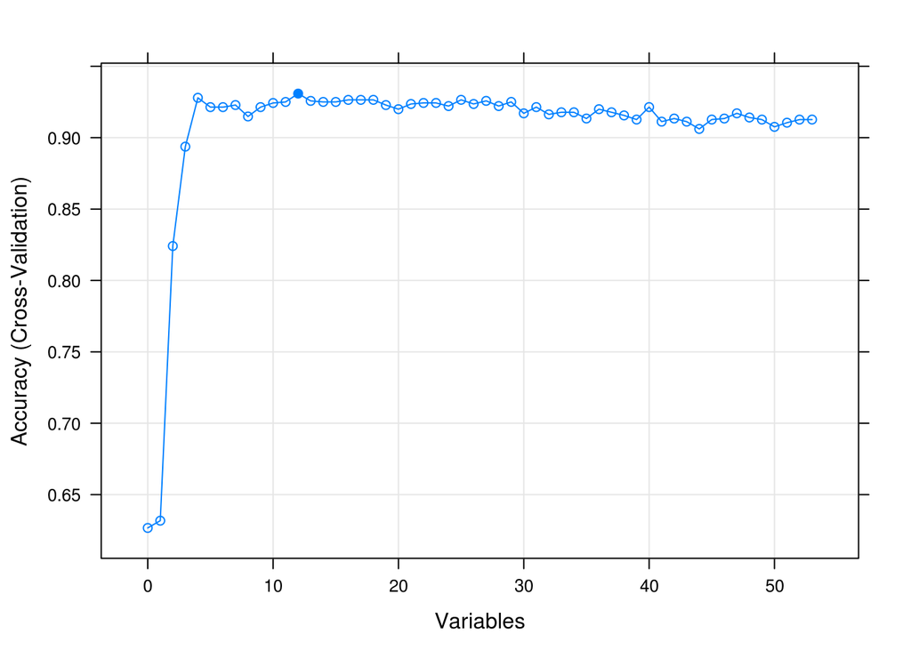

```r
plot(results, type=c("g", "o"))
```

The result shows that add several feature to train, accuracy improve rappidly. In the peak of accuracy, the number of feature is around 10, and too many features led to poor performance.

### model fitting by random forest

```r
set.seed(12345)
control_rf <- trainControl(method="cv", number=3, verboseIter=T)
mod_rf <- train(classe ~ ., data=TrainSet, method="rf", trControl=control_rf)
mod_rf$finalModel
```

```
##
## Call:
##  randomForest(x = x, y = y, mtry = param$mtry)
##                Type of random forest: classification
##                      Number of trees: 500
## No. of variables tried at each split: 27
##
##         OOB estimate of  error rate: 0.18%
## Confusion matrix:
##      A    B    C    D    E  class.error
## A 3904    1    0    0    1 0.0005120328
## B    5 2651    2    0    0 0.0026335591
## C    0    5 2390    1    0 0.0025041736
## D    0    0    7 2245    0 0.0031083481
## E    0    0    0    3 2522 0.0011881188
```

#### prediction on Test dataset and performance evaluation

```r
pred_rf <- predict(mod_rf, newdata=TestSet)
confmat_rf <- confusionMatrix(pred_rf, TestSet$classe)
confmat_rf
```

```
## Confusion Matrix and Statistics
##
##           Reference
## Prediction    A    B    C    D    E
##          A 1674    5    0    0    0
##          B    0 1133    3    0    0
##          C    0    1 1023    7    0
##          D    0    0    0  957    3
##          E    0    0    0    0 1079
##
## Overall Statistics
##
##                Accuracy : 0.9968
##                  95% CI : (0.995, 0.9981)
##     No Information Rate : 0.2845
##     P-Value [Acc > NIR] : < 2.2e-16
##
##                   Kappa : 0.9959
##  Mcnemar's Test P-Value : NA
##
## Statistics by Class:
##
##                      Class: A Class: B Class: C Class: D Class: E
## Sensitivity            1.0000   0.9947   0.9971   0.9927   0.9972
## Specificity            0.9988   0.9994   0.9984   0.9994   1.0000
## Pos Pred Value         0.9970   0.9974   0.9922   0.9969   1.0000
## Neg Pred Value         1.0000   0.9987   0.9994   0.9986   0.9994
## Prevalence             0.2845   0.1935   0.1743   0.1638   0.1839
## Detection Rate         0.2845   0.1925   0.1738   0.1626   0.1833
## Detection Prevalence   0.2853   0.1930   0.1752   0.1631   0.1833
## Balanced Accuracy      0.9994   0.9971   0.9977   0.9961   0.9986
```

### model fitting by random forest for feature selected data

```r
set.seed(12345)

data_rfe <- TrainSet[results$optVariables]
data_rfe$classe <- TrainSet$classe

mod_rf_rfe <- train(classe ~ ., data=data_rfe, method="rf", trControl=control_rf)
mod_rf_rfe$finalModel
```

```
##
## Call:
##  randomForest(x = x, y = y, mtry = param$mtry)
##                Type of random forest: classification
##                      Number of trees: 500
## No. of variables tried at each split: 7
##
##         OOB estimate of  error rate: 0.21%
## Confusion matrix:
##      A    B    C    D    E  class.error
## A 3905    1    0    0    0 0.0002560164
## B    6 2646    6    0    0 0.0045146727
## C    0    4 2392    0    0 0.0016694491
## D    0    0    5 2247    0 0.0022202487
## E    0    1    0    6 2518 0.0027722772
```

#### prediction on Test dataset and performance evaluation

```r
pred_rf_rfe <- predict(mod_rf_rfe, newdata=TestSet)
confmat_rf_rfe <- confusionMatrix(pred_rf_rfe, TestSet$classe)
confmat_rf_rfe
```

```
## Confusion Matrix and Statistics
##
##           Reference
## Prediction    A    B    C    D    E
##          A 1674    3    0    0    0
##          B    0 1133    2    0    0
##          C    0    3 1024    2    0
##          D    0    0    0  962    1
##          E    0    0    0    0 1081
##
## Overall Statistics
##
##                Accuracy : 0.9981
##                  95% CI : (0.9967, 0.9991)
##     No Information Rate : 0.2845
##     P-Value [Acc > NIR] : < 2.2e-16
##
##                   Kappa : 0.9976
##  Mcnemar's Test P-Value : NA
##
## Statistics by Class:
##
##                      Class: A Class: B Class: C Class: D Class: E
## Sensitivity            1.0000   0.9947   0.9981   0.9979   0.9991
## Specificity            0.9993   0.9996   0.9990   0.9998   1.0000
## Pos Pred Value         0.9982   0.9982   0.9951   0.9990   1.0000
## Neg Pred Value         1.0000   0.9987   0.9996   0.9996   0.9998
## Prevalence             0.2845   0.1935   0.1743   0.1638   0.1839
## Detection Rate         0.2845   0.1925   0.1740   0.1635   0.1837
## Detection Prevalence   0.2850   0.1929   0.1749   0.1636   0.1837
## Balanced Accuracy      0.9996   0.9972   0.9985   0.9989   0.9995
```

Accuracy of feature selected by recursive feature elimination are higher than no feature selected.

## Prediction of test data

```r
pred_rf_rfe_test <- predict(mod_rf_rfe, newdata=testing)
pred_rf_rfe_test
```

```
##  [1] B A B A A E D B A A B C B A E E A B B B
## Levels: A B C D E
```

## Conclusion

I tried to fit random forest model to the Weight Lifting Exercises Dataset to predict human activity. I used feature selection to increase accuracy and robustness of learned model. I predicted test data by learned model(with feature selection).